# SMS Spam Identifier

Achmad Gunar Saadi

September 25, 2018

# 1 Intro of Capstone Project: “SMS Spam Identifier”

In this project, we are going to build a classification model to create a spam classifier.The dataset is a real SMS dataset with spam/ ham label for each message.  
Making a report of the approach you use in building the model classifier. The report should have a clear explanation of:  
- *Data Preprocess*  
Show how you feature engineered the attributes you are going to use in your model.  
- *Model Selection*  
In building the model, we should consider multiple parameters in coming up with the best model.  
- *Predicting Spam SMS*  
Based on the best model picked in previous step, use the model to predict SMS messages stored in `data/submissionSMS.csv`.

*Rubric*:  
Achieve at least 90% of precision on unseen data  
Achieve at least 80% of accuracy on unseen data  
Achieve at least 80% of recall on unseen data  
Achieve at least 85% of specificity on unseen data

# 2 Data Preprocess

```r
library(lubridate)
msg <- read.csv("./sms.csv")
head(msg$DATE)
```

```
## [1] 2018-02-28 11:43:00 2018-02-28 11:43:00 2018-02-28 01:52:00
## [4] 2018-02-27 15:21:00 2018-02-27 12:22:00 2018-02-27 12:05:00
## 1532 Levels: 2017-02-15 14:48:00 2017-02-15 15:24:00 ... 2018-02-28 11:43:00
```

```r
dim(msg)
```

```
## [1] 1805    3
```

```r
names(msg)
```

```
## [1] "STATUS"  "CONTAIN" "DATE"
```

```r
str(msg)
```

```
## 'data.frame':    1805 obs. of  3 variables:
##  $ STATUS : Factor w/ 2 levels "ham","spam": 1 1 2 1 2 2 2 2 2 2 ...
##  $ CONTAIN: Factor w/ 1530 levels "'GRATIS YouTube & Instagram selama 3 hari hanya di aplikasi myIM3. Download aplikasinya sekarang di http://bit.ly/myim3arn",..: 1344 838 734 1446 811 1157 734 525 1218 1456 ...
##  $ DATE   : Factor w/ 1532 levels "2017-02-15 14:48:00",..: 1532 1532 1531 1530 1529 1528 1527 1526 1525 1524 ...
```

```r
summary(msg)
```

```
##   STATUS
##  ham :1140
##  spam: 665
##
##
##
##
##
##                                                                                                                                                              CONTAIN
##  usage                                                                                                                                                           :  24
##  Ok                                                                                                                                                              :  11
##  Gojek d tunggu otw penjemputan                                                                                                                                  :  10
##  Pulsamu <Rp500.Mau PULSA SOS 10000 bs dipakai ke SemuaOperator sd 5hr?Pembayaran Rp10000 & BeaJasa Rp3000 akan dipotong saat isi Pulsa.Balas YA ke 505 /tkn*505#:   9
##  Km baru saja akses Apps Sehari-hari terpopuler.Nikmati akses YOUTUBE ga habis habis dgn beli pkt Unlimited HANYA di *123# atau myIM3 http://im3.do/m3           :   8
##  Pelanggan Yth, Pulsa Anda tdk cukup. Tersedia PULSA SIAGA utk Anda, pembyran dilakukan saat isi pulsa, hub *911# atau bls SMS ini ktk 0                         :   7
##  (Other)                                                                                                                                                         :1736
##                   DATE
##  2017-12-09 15:20:00:   9
##  2017-11-27 19:41:00:   5
##  2018-01-06 17:19:00:   5
##  2018-01-17 10:35:00:   5
##  2017-03-17 12:37:00:   4
##  2017-07-15 07:03:00:   4
##  (Other)            :1773
```

```r
head(msg$CONTAIN)
```

```
## [1] Sy wa ga sampe2 soalnya
## [2] Mbak tiara sy da di cyber yaa.. di starbuck
## [3] Km baru saja akses Apps Sehari-hari terpopuler.Nikmati akses YOUTUBE ga habis habis dgn beli pkt Unlimited HANYA di *123# atau myIM3 http://im3.do/m3
## [4] Trm ksh Anda sdh akses Facebook dgn IndosatOoredoo. Brdasar pngalamn Anda, sberapa puas Anda thdp kualitas akses FB kami? Balas F1 sd F5 (F5= Sgt puas). FREE
## [5] Mau nongkrong bareng teman di tanggal tua? Ayo tekan *123*510*3# . Dapatkan DISKON & GRATIS Nelp 60 menit. Trf Rp2.200/3hr. Info: 02172784605 SPI15
## [6] Saksikan Final Coppa Italia 2017/2018 SuperBigMatch babak Semifinal Leg ke-2, Juventus VS Atalanta hanya di GENFLIX. Tekan *123*519*4#. CS: 08041911911  SPI13
## 1530 Levels: 'GRATIS YouTube & Instagram selama 3 hari hanya di aplikasi myIM3. Download aplikasinya sekarang di http://bit.ly/myim3arn ...
```

```r
tail(msg$CONTAIN)
```

```
## [1] oke deh, makasih dok
## [2] iya boleh dok gapapa, besok setengah 9 bisa?
## [3] kalau bisa malam boleh sih, setengah 9 gitu bisa ya? ga buru-buru juga sih, dokter bisanya mulai kapan kalau mau dijadwalkan?
## [4] iya dr indah, saya rumahnya di bukit permai. Jadi saya kalau weekday kerja, pulangnya malam jam 8 kira-kira baru sampai rumah. Kalau dipanggil gt bisa malam ngga ya? atau lebih baik saya titipin ke yg jaga rumah aja, saya tinggalin notes buat keluhan per kucingnya?
## [5] Sore, ini dengan drh yg di Jambore ya? dengan dokter siapa ya? saya mau tanya kalau untuk biaya panggil ke rumah itu dihitung per kucing atau per datangnya ya? makasih.
## [6] nanti saya ke depan gerbang bukit permai yg ditutup, yg di sebelah kimia farma ya, Pak
## 1530 Levels: 'GRATIS YouTube & Instagram selama 3 hari hanya di aplikasi myIM3. Download aplikasinya sekarang di http://bit.ly/myim3arn ...
```

The dataset contains 1805 observations and 3 columns (DATE,CONTAIN,STATUS). The `DATE` attribute contain timestamp (date and time) SMS received information in **YMD-HMS** format. The `CONTAIN` attribute store the texts of SMS received. While the label whether spam (unwanted SMS) or ham stored in `STATUS` attribute. All the attributes are in Factor class. `STATUS` has 2 levels, while `CONTAIN` and `DATE` have 1530 and 1532 levels respectively. The dataset range from 15th February 2017 to 28th February 2018.

```r
dt<-parse_date_time(msg$DATE, orders = "ymd HMS")
dt.d<-as.Date(dt)
dt.h<-hour(dt)
dt.m<-minute(dt)
range(dt.d)
```

```
## [1] "2017-02-15" "2018-02-28"
```

Here, the dataset is redefined into new dataframe structure and stored in `msg`. The new dataframe contains `Date`,`Hour`,`Minute`,`Contain`,and `Status` attributes.

```r
# redefine the data frame
msg<-data.frame("Date"=dt.d,"Hour"=dt.h, "Minute"=dt.m,"Contain"=msg$CONTAIN,"Status"=msg$STATUS)
head(msg)
```

```
##         Date Hour Minute
## 1 2018-02-28   11     43
## 2 2018-02-28   11     43
## 3 2018-02-28    1     52
## 4 2018-02-27   15     21
## 5 2018-02-27   12     22
## 6 2018-02-27   12      5
##                                                                                                                                                          Contain
## 1                                                                                                                                        Sy wa ga sampe2 soalnya
## 2                                                                                                                    Mbak tiara sy da di cyber yaa.. di starbuck
## 3          Km baru saja akses Apps Sehari-hari terpopuler.Nikmati akses YOUTUBE ga habis habis dgn beli pkt Unlimited HANYA di *123# atau myIM3 http://im3.do/m3
## 4  Trm ksh Anda sdh akses Facebook dgn IndosatOoredoo. Brdasar pngalamn Anda, sberapa puas Anda thdp kualitas akses FB kami? Balas F1 sd F5 (F5= Sgt puas). FREE
## 5            Mau nongkrong bareng teman di tanggal tua? Ayo tekan *123*510*3# . Dapatkan DISKON & GRATIS Nelp 60 menit. Trf Rp2.200/3hr. Info: 02172784605 SPI15
## 6 Saksikan Final Coppa Italia 2017/2018 SuperBigMatch babak Semifinal Leg ke-2, Juventus VS Atalanta hanya di GENFLIX. Tekan *123*519*4#. CS: 08041911911  SPI13
##   Status
## 1    ham
## 2    ham
## 3   spam
## 4    ham
## 5   spam
## 6   spam
```

## 2.1 Text Mining

Creating the corpus using VCorpus function. Then, create a customized function, `transformer`, that commbine the application of content_transformer and gsub functions which is convert some pattern into white space (" “).

```r
library(tm)
#Create corpus object
msg.corpus <- VCorpus(VectorSource(msg$Contain))
msg.corpus[[1]]$content
```

```
## [1] "Sy wa ga sampe2 soalnya"
```

```r
# Create a custom transformer to substitute punctuations with a space (" ")
transformer <- content_transformer(function(x, pattern) {
    gsub(pattern, " ", x)
})
# Create a function to substitute URL with a space (" ")
removeURL<-function(x){
  gsub("http[^[[:space:]]*"," ",x)
}
```

### 2.1.1 Data Cleansing

To make the data text more uniform in format and structure, conducted means as below: - Convert all text into lowercase  
- Remove number - Substitute the newline punctuation (**“\n”**) with white space using transformer function - Remove stopwords (the list of words are in file `stopwords-id.txt`)  
- Substitute common punctuations such as: **“.”, “/”, “@”, and “-”** with a white space using transformer function  
- Remove other common punctuations using built-in function in R  
- Separate words by a white space using `stemDocument` and `stripWhitespace`

```r
# data cleansing
# convert all text to lowercase
msg.corpus <- tm_map(msg.corpus, content_transformer(tolower))
# Remove numbers and punctuations
msg.corpus <- tm_map(msg.corpus, removeNumbers)
msg.corpus <- tm_map(msg.corpus, transformer, "\\n")
# Remove stopwords
stopwords <- readLines("./stopwords-id.txt")
msg.corpus <- tm_map(msg.corpus, removeWords, stopwords)

# Substitute ".", "/", "@", common punctuations, and URL with a white space (" ")
msg.corpus<- tm_map(msg.corpus, transformer, "/")
msg.corpus <- tm_map(msg.corpus, transformer, "@")
msg.corpus <- tm_map(msg.corpus, transformer, "-")
msg.corpus <- tm_map(msg.corpus, transformer, "\\.")
msg.corpus <- tm_map(msg.corpus,content_transformer(removeURL) )
# For all other punctuations, simply strip them using the built-in function
msg.corpus.new <- tm_map(msg.corpus, removePunctuation)

#Separate words by one whitespace
msg.corpus.new <- tm_map(msg.corpus.new, stemDocument)
msg.corpus.new <- tm_map(msg.corpus.new, stripWhitespace)
```

### 2.1.2 Stemming (Lemmatization) and Tokenization

The stemming process using function in katadasaR library, which can be accessed by clicking [this link](https://github.com/nurandi/katadasaR)  
After that, the tokenization is conducted for splitting each corpus element into individual phrases by using DocumentTermMatrix function that resulting in Document Term Matrix (DTM).  
As for the next preprocessing, by using findFreqTerms function, the possible noise can be reduce through filtering that words processed are words that appeared in at least 30 messages.

```r
#stemming
library(katadasaR)

stem_bahasa<-content_transformer(function(x){
  paste(sapply(words(x), katadasar),collapse = " ")
})
msg.stem<-tm_map(msg.corpus.new,stem_bahasa)

# Tokenization
msg.dtm <- DocumentTermMatrix(msg.stem)
x<-inspect(msg.dtm)
```

```
## <<DocumentTermMatrix (documents: 1805, terms: 2287)>>
## Non-/sparse entries: 14544/4113491
## Sparsity           : 100%
## Maximal term length: 27
## Weighting          : term frequency (tf)
## Sample             :
##       Terms
## Docs   beli bonus dgn info internet kuota nikmat paket sms utk
##   1112    0     1   1    2        0     0      0     2   0   0
##   1158    0     0   0    0        1     0      0     0   0   0
##   1178    0     0   0    0        0     0      0     0   1   0
##   1181    0     0   0    0        0     0      0     0   0   0
##   1611    0     0   0    0        0     0      0     0   0   0
##   1644    0     0   0    0        0     0      0     0   0   0
##   1803    0     0   0    0        0     0      0     0   0   0
##   297     0     0   0    0        0     2      0     1   1   1
##   470     0     0   0    0        0     2      0     1   1   1
##   903     2     0   1    0        1     0      1     0   0   1
```

```r
msg_freq<-findFreqTerms(msg.dtm,30)
```

```r
mm <- as.matrix(msg.dtm)
vv <- sort(rowSums(mm),decreasing=TRUE)
dd <- data.frame(word = names(vv),freq=vv)
```

## 2.2 Splitting into Training and Test Set

```r
set.seed(10)
ind_split <- sample(nrow(msg.dtm), nrow(msg.dtm)*0.80)
msg_train <- msg.dtm[ind_split, ]
msg_test <- msg.dtm[-ind_split, ]
dim(msg_train)
```

```
## [1] 1444 2287
```

```r
dim(msg_test)
```

```
## [1]  361 2287
```

```r
train_label <- msg[ind_split, 5]
test_label <- msg[-ind_split,5]

table(train_label)
```

```
## train_label
##  ham spam
##  898  546
```

```r
prop.table(table(train_label))
```

```
## train_label
##       ham      spam
## 0.6218837 0.3781163
```

We’ll then subset our training and test set to get all the rows (corresponding to documents) but only include columns (terms) where they have appeared in at least 30 messages.

```r
msg_train <- msg_train[,msg_freq]
msg_test <- msg_test[,msg_freq]
```

Creating an own-designed function named bernoulli_conv that converts every word that at least has value of 1 or more into 1 (one). Otherwise, the value is 0 (zero). So, the function produces a binomial vector.

```r
bernoulli_conv <- function(x){
  x <- ifelse(x>=1,1,0)
}
train_bn <- apply(msg_train, 2, bernoulli_conv)
test_bn <- apply(msg_test, 2, bernoulli_conv)
```

# 3 Model Selection

## 3.1 Naive Bayes Algorithm

Check whether in training and test set there are some words that have 0 (zero) value. Because based on Naive Bayes algorithm, even just one event with zero-probability (zero appearance) in DTM can leads to zero value for the final result. Thus, zero-probability must be avoided. One of the solutions is by using laplace smoothing later in our model construction.

```r
num_train <- colSums(apply(train_bn, 2, as.numeric))
num_test <- colSums(apply(test_bn, 2, as.numeric))
```

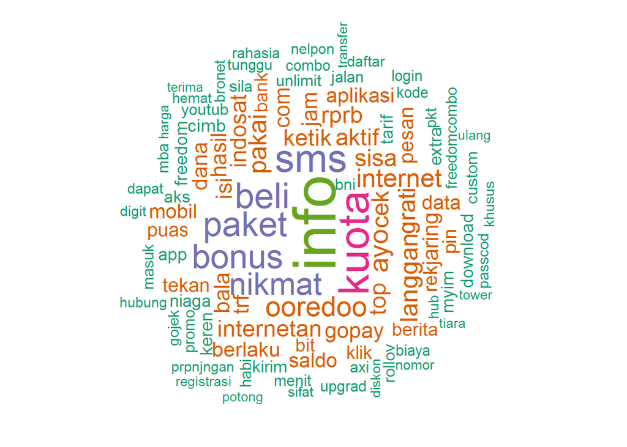

```r
library("wordcloud")
library("RColorBrewer")
# Drop unnecessary words in training set
drops<-c("aja","bls","dgn","dpt","ire","lho","maaf","mai","pai","skrg","tdk","utk")
ntrain<-num_train[!(names(num_train) %in% drops)]
# Creating Word Cloud in training set
wordcloud(words = names(ntrain), freq = ntrain, min.freq = 1,
          max.words=100, random.order=F, rot.per=0.45,
          colors=brewer.pal(5, "Dark2"))
```

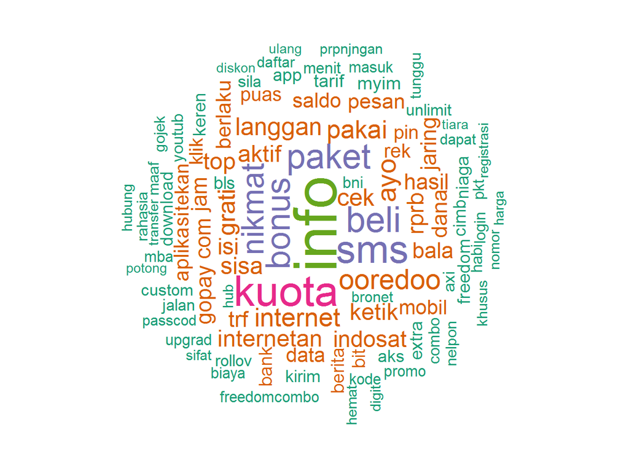

```r
# Drop unnecessary words in test set
drops<-c("aja","dgn","dpt","ire","lho","mai","pai","skrg","tdk","utk")
ntest<-num_train[!(names(num_train) %in% drops)]
# Creating Word Cloud in test set
wordcloud(words = names(ntest), freq = ntest, min.freq = 1,
          max.words=100, random.order=F, rot.per=0.45,
          colors=brewer.pal(5, "Dark2"))
```

In the checking process, we found that there is no zero-probability in both training and test set. But even so, we still will run the laplace smooting to anticipate the zero-probability in the `submissionSMS.csv` file.

```r
num_train[num_train < 1]
```

```
## named numeric(0)
```

```r
num_test[num_test < 1]
```

```
## named numeric(0)
```

Execute the naiveBayes function to obtain the model through Naive Bayes algorithm.

```r
library(e1071)
spam_model <- naiveBayes(train_bn, train_label, laplace = 1)
# Predict
spam_prediction <- predict(spam_model, test_bn)
```

Model performance Evaluation through confusion matrix and ROC.

```r
table(prediction = spam_prediction, actual=test_label)
```

```
##           actual
## prediction ham spam
##       ham  219   10
##       spam  23  109
```

```r
TN<-sum(spam_prediction == 'ham'&test_label=='ham')
FN<-sum(spam_prediction == 'ham'&test_label=='spam')
TP<-sum(spam_prediction == 'spam'&test_label=='spam')
FP<-sum(spam_prediction == 'spam'&test_label=='ham')
```

```r
#precision
TP/(TP+FP)*100
```

```
## [1] 82.57576
```

```r
#accuracy
(TN+TP)/length(test_label)*100
```

```
## [1] 90.85873
```

```r
#recall/ sensitivity
TP/(TP+FN)*100
```

```
## [1] 91.59664
```

```r
#Specificity
TN/(TN+FP)*100
```

```
## [1] 90.49587
```

```r
library(caret)
confusionMatrix(as.factor(spam_prediction),as.factor(test_label))
```

```
## Confusion Matrix and Statistics
##
##           Reference
## Prediction ham spam
##       ham  219   10
##       spam  23  109
##
##                Accuracy : 0.9086
##                  95% CI : (0.874, 0.9362)
##     No Information Rate : 0.6704
##     P-Value [Acc > NIR] : < 2e-16
##
##                   Kappa : 0.7987
##  Mcnemar's Test P-Value : 0.03671
##
##             Sensitivity : 0.9050
##             Specificity : 0.9160
##          Pos Pred Value : 0.9563
##          Neg Pred Value : 0.8258
##              Prevalence : 0.6704
##          Detection Rate : 0.6066
##    Detection Prevalence : 0.6343
##       Balanced Accuracy : 0.9105
##
##        'Positive' Class : ham
##
```

```r
spam_prediction_raw <- predict(spam_model, test_bn, type = "raw")
head(spam_prediction_raw)
```

```
##                ham         spam
## [1,]  1.000000e+00 4.963254e-30
## [2,] 4.799404e-138 1.000000e+00
## [3,]  0.000000e+00 1.000000e+00
## [4,] 1.252465e-184 1.000000e+00
## [5,]  0.000000e+00 1.000000e+00
## [6,]  8.499321e-20 1.000000e+00
```

```r
# Plot ROC Curve
spam_df <- data.frame("prediction"=spam_prediction_raw[,2], "trueclass"=as.numeric(test_label=="spam"))
head(spam_df)
```

```
##     prediction trueclass
## 1 4.963254e-30         0
## 2 1.000000e+00         0
## 3 1.000000e+00         1
## 4 1.000000e+00         1
## 5 1.000000e+00         1
## 6 1.000000e+00         1
```

```r
library(ROCR)
```

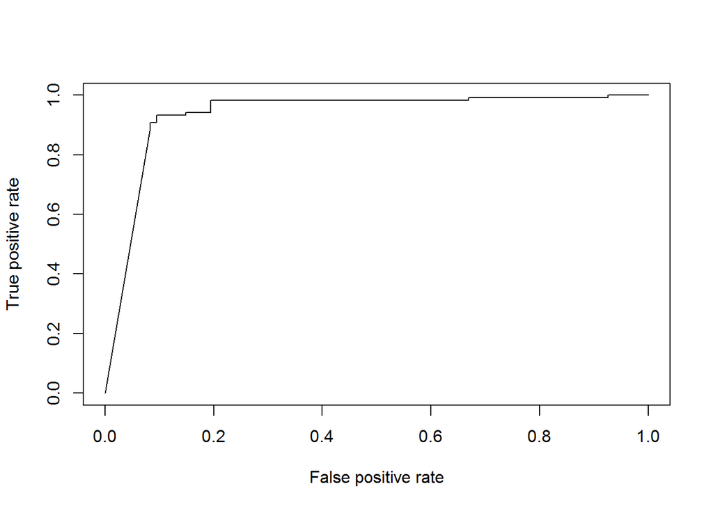

```r
spam_roc <- ROCR::prediction(spam_df$prediction, spam_df$trueclass)
plot(performance(spam_roc, "tpr", "fpr"))
```

# 4 Prediction Spam

Based on the best model picked in previous step (Naive Bayes Algorithm), use the model to predict SMS messages stored in `./submissionSMS.csv`. The prediction should contain 2 classes: *spam* or *ham*. The forecasted prediction should be filled in under `STATUS` column in the same file.

The dataset contains 323 observations and 3 columns (DATE,CONTAIN,STATUS). The `DATE` attribute contain timestamp (date and time) SMS received information in **YMD-HMS** format. The `CONTAIN` attribute store the texts of SMS received. While the `STATUS` attribute still empty and need to fill by the prediction final result. The dataset range from 28th February 2018 to 25th April 2018. That means the `submissionSMS.csv` dataset cover the data from the end of the date of `sms.csv` to two months ahead.

```r
library(lubridate)
sms.s <- read.csv("./submissionSMS.csv")
head(sms.s)
```

```
##                  DATE
## 1 2018-04-25 14:20:00
## 2 2018-04-25 14:13:00
## 3 2018-04-25 12:26:00
## 4 2018-04-25 12:08:00
## 5 2018-04-24 12:41:00
## 6 2018-04-24 11:42:00
##                                                                                                                                                            CONTAIN
## 1  ELITE RELOAD PULSA:Kami ingin menawarkan anda menjadi agen pulsa all operator. harga: V5:4750,V10:8750,V20:18750.Minat invite BBM: D995290A & WA: 085656345887.
## 2                                                               iRing keren cuman buat km, Feni Rose-TERCYDUK,Rp.0,1/3hr prpnjngan Rp.3190 dengan hnya bls YA lho!
## 3    Sahabat, registrasi kartu SIM prabayar Anda SEKARANG. Ketik ULANG#NIK#No.KK# SMS ke 4444 atau klik http://im3.do/registrasi s.d. 30 April 2018. Terima kasih.
## 4                                                                                                    sians text ULANG#NIK#No.KK# to 4444.Foreigners bring Passport
## 5 24/04/2018 12:41 Pada No. Rek 378088918 ada dana keluar sebesar Rp 100.000,00. Saldo akhir: Rp 216.309,00.Berita: BILL PAYMENT  GOPAY CUST    NO  39152454823092
## 6  Sisa kuota GAK AKAN HANGUS & dpt disimpan hg 100GB SETAHUN dgn DATAROLLOVER dr IM3Ooredoo!Gratis dgn pkt Internet bulanan IM3 Ooredoo http://im3.do/dr0424 BMI1
##   STATUS
## 1     NA
## 2     NA
## 3     NA
## 4     NA
## 5     NA
## 6     NA
```

```r
dim(sms.s)
```

```
## [1] 323   3
```

```r
str(sms.s)
```

```
## 'data.frame':    323 obs. of  3 variables:
##  $ DATE   : Factor w/ 303 levels "2018-02-28 22:22:00",..: 303 302 301 300 299 298 297 296 295 294 ...
##  $ CONTAIN: Factor w/ 227 levels " Test","(AXIS) Kamu sdg internetan tanpa paket internet. Pulsa kamu saat ini 75. Lebih IRIT dgn aktifkan paket Internet"| __truncated__,..: 75 105 181 184 22 191 181 194 184 131 ...
##  $ STATUS : logi  NA NA NA NA NA NA ...
```

```r
summary(sms.s)
```

```
##                   DATE
##  2018-03-25 21:33:00:  4
##  2018-03-21 11:18:00:  3
##  2018-03-21 12:23:00:  3
##  2018-04-23 20:14:00:  3
##  2018-03-05 13:18:00:  2
##  2018-03-08 09:51:00:  2
##  (Other)            :306
##                                                                                                                                                             CONTAIN
##  AGAR TDK DIBLOKIR,sgr registrasi ulang kartu prabayar Anda.Tlp dan SMS keluar diblokir mulai 1-31 Maret 2018.Ketik ULANG#NIK#No.KK SMS ke 4444.Info 838        : 21
##  AGAR TIDAK DIBLOKIR, segera registrasi ulang kartu prabayar Anda. Telepon & SMS keluar diblokir mulai 1-31 Maret 2018. Ketik: ULANG#NIK#nomorKK#  SMS ke 4444  :  9
##  Proses PEMBLOKIRAN bg yg blm REGISTRASI sdg berjalan. SEGERA  REGISTRASI ULANG. Dptkan BONUS 10GB+Nelpon&SMS sepuasnya u/3hr. Ketik ULANG#NIK#No.KK# SMS ke4444:  8
##  Pelanggan Yth, Pulsa Anda tdk mencukupi. Tersedia PULSA SIAGA utk Anda, pembyran dilakukan saat isi pulsa, hub *911# atau bls SMS ini ktk 0                    :  6
##  AXIS Berbagi DISKON! Bronet 24jam 2GB CUMA 25rb,30hr (Norm 30,900) Balas YA, utk dapetin skrg. Internetan makin eksis krn diskon dr AXIS! Info838 AND01A       :  5
##  Kamu blm REG. Segera REGISTRASI ULANG.Pemblokiran mulai Senin 26Mar18.Ketik ULANG#NIK#No.KK# SMS ke 4444. Dptkn BNS 10GB+Nelp&SMS sepuasnya. Abaikan jk sdh REG:  5
##  (Other)                                                                                                                                                        :269
##   STATUS
##  Mode:logical
##  NA's:323
##
##
##
##
##
```

```r
dt<-parse_date_time(sms.s$DATE, orders = "ymd HMS")
dt.d<-as.Date(dt)
dt.h<-hour(dt)
dt.m<-minute(dt)
range(dt.d)
```

```
## [1] "2018-02-28" "2018-04-25"
```

Here, the dataset is redefined into new dataframe structure and stored in `msgg`. The new dataframe contains `Date`,`Hour`,`Minute`,`Contain`,and `Status` attributes.

```r
# redefine the data frame
msgg<-data.frame("Date"=dt.d,"Hour"=dt.h, "Minute"=dt.m,"Contain"=sms.s$CONTAIN,"Status"=sms.s$STATUS)
head(msgg)
```

```
##         Date Hour Minute
## 1 2018-04-25   14     20
## 2 2018-04-25   14     13
## 3 2018-04-25   12     26
## 4 2018-04-25   12      8
## 5 2018-04-24   12     41
## 6 2018-04-24   11     42
##                                                                                                                                                            Contain
## 1  ELITE RELOAD PULSA:Kami ingin menawarkan anda menjadi agen pulsa all operator. harga: V5:4750,V10:8750,V20:18750.Minat invite BBM: D995290A & WA: 085656345887.
## 2                                                               iRing keren cuman buat km, Feni Rose-TERCYDUK,Rp.0,1/3hr prpnjngan Rp.3190 dengan hnya bls YA lho!
## 3    Sahabat, registrasi kartu SIM prabayar Anda SEKARANG. Ketik ULANG#NIK#No.KK# SMS ke 4444 atau klik http://im3.do/registrasi s.d. 30 April 2018. Terima kasih.
## 4                                                                                                    sians text ULANG#NIK#No.KK# to 4444.Foreigners bring Passport
## 5 24/04/2018 12:41 Pada No. Rek 378088918 ada dana keluar sebesar Rp 100.000,00. Saldo akhir: Rp 216.309,00.Berita: BILL PAYMENT  GOPAY CUST    NO  39152454823092
## 6  Sisa kuota GAK AKAN HANGUS & dpt disimpan hg 100GB SETAHUN dgn DATAROLLOVER dr IM3Ooredoo!Gratis dgn pkt Internet bulanan IM3 Ooredoo http://im3.do/dr0424 BMI1
##   Status
## 1     NA
## 2     NA
## 3     NA
## 4     NA
## 5     NA
## 6     NA
```

## 4.1 Text Mining

Overall, the steps in text mining same as in previous dataset.  
That covers creating corpus, transformer function, and data cleansing.

```r
library(tm)

#Create corpus object
msgg.corpus <- VCorpus(VectorSource(msgg$Contain))
msgg.corpus[[1]]$content
```

```
## [1] "ELITE RELOAD PULSA:Kami ingin menawarkan anda menjadi agen pulsa all operator. harga: V5:4750,V10:8750,V20:18750.Minat invite BBM: D995290A & WA: 085656345887."
```

```r
# data cleansing
# convert all text to lowercase
msgg.corpus <- tm_map(msgg.corpus, content_transformer(tolower))
# Remove numbers and punctuations
msgg.corpus <- tm_map(msgg.corpus, removeNumbers)
msgg.corpus <- tm_map(msgg.corpus, transformer, "\\n")
# Remove stopwords
stopwords <- readLines("./stopwords-id.txt")
msgg.corpus <- tm_map(msgg.corpus, removeWords, stopwords)

# Substitute ".", "/", "@" and common punctuations with a white space (" ")
msgg.corpus<- tm_map(msgg.corpus, transformer, "/")
msgg.corpus <- tm_map(msgg.corpus, transformer, "@")
msgg.corpus <- tm_map(msgg.corpus, transformer, "-")
msgg.corpus <- tm_map(msgg.corpus, transformer, "\\.")
# For all other punctuations, simply strip them using the built-in function
msgg.corpus.new <- tm_map(msgg.corpus, removePunctuation)

#Separate words by one whitespace
msgg.corpus.new <- tm_map(msgg.corpus.new, stemDocument)
msgg.corpus.new <- tm_map(msgg.corpus.new, stripWhitespace)
msgg.corpus.new[[1]]$content
```

```
## [1] "elit reload menawarkan agen all oper harga vvv minat invit bbm da wa"
```

The stemming process still the same, using function in katadasaR library.  
As for the tokenization, we’d use dictionary list extracted from train data in creating DTM to make sure token attributes used in both train and test are the same.  
By using findFreqTerms function, the possible noise can be reduce through filtering that words processed are words that appeared in at least 30 messages.

```r
#stemming
library(katadasaR)

stem_bahasa<-content_transformer(function(x){
  paste(sapply(words(x), katadasar),collapse = " ")
})
msgg.stem<-tm_map(msgg.corpus.new,stem_bahasa)

# Tokenization
dtm <- DocumentTermMatrix(msg.stem)
freqTerms<-findFreqTerms(dtm,30)
reduced_dtm<-DocumentTermMatrix(msgg.stem, list(dictionary=freqTerms))
```

```r
bernoulli_conv <- function(x){
  x <- ifelse(x>=1,1,0)
}
msgg.dtm<-apply(reduced_dtm,2,bernoulli_conv)
```

From the checking process, we found that there are some words with zero appearance in DTM. That is why need Laplace Smoothing to avoid zero-probability.

```r
# Check whether need Laplace Smoothing
num <- colSums(apply(msgg.dtm, 2, as.numeric))
num[num < 1]
```

```
##          bni        combo       daftar        digit        extra
##            0            0            0            0            0
## freedomcombo          mai        menit          pai       paypro
##            0            0            0            0            0
##      spotifi        tcash     transfer       tunggu       upgrad
##            0            0            0            0            0
```

```r
# Predict
submitted_prediction <- predict(spam_model, msgg.dtm, type = "raw")

aaa<-as.data.frame(submitted_prediction)
for (i in c(1:nrow(sms.s))){
  ifelse(as.numeric(aaa[i,2]>=0.25)==1,sms.s$STATUS[i]<-"spam",
                    sms.s$STATUS[i]<-"ham")
}

cat("\nSTATUS Proportion with Threshold 0.25 :")
```

```
##
## STATUS Proportion with Threshold 0.25 :
```

```r
prop.table(table(sms.s$STATUS))
```

```
##
##       ham      spam
## 0.4179567 0.5820433
```

Writing submission csv submission file.

```r
write.csv(sms.s,"SMS_Classification.csv")
```